# Search Strategy in Grain Boundary Search Task (E1)

Dave Braun

February 8, 2022

This document was last updated on 2022-03-21 13:40:36.

In this document, we are exploring whether there might be individual differences in search strategies. The primary difference in strategy we are considering has to do with how the time of search is distributed throughout the search period. We hypothesize some people may invest more time to search the array in the initial viewing period, whereas other people may invest more of their search time clicking around the array in more of a trial-and-error approach.

I’m going to refer to the period that the can view the array prior to selecting lines as *view period*.

```r
d <- read.csv('../../data/exp1_long_data.csv')
thinnest_lines <- read.csv('../../data/thinnest_lines.csv')
source('../compute_accuracy_columns.r')
d <- compute_accuracy_columns(d, thinnest_lines)
N <- length(unique(d$participant))
head(d)
```

|  | participant | date | overall_time | trial_count | click_order | prompt_rt_sec | selection_rt_ms | pressed_object | line_width | top_x | top_y | bottom_x | bottom_y | line_id | line_orientation | selected_or_released | accuracy | possible_thinnest_lines | is_practice | drop_marker | indecision_trial | accuracy_type |
| --- | --- | --- | --- | --- | --- | --- | --- | --- | --- | --- | --- | --- | --- | --- | --- | --- | --- | --- | --- | --- | --- | --- |
| 1 | 10 | 2021_Oct_01_1059 | 0 days 00:31:04.465510000 | 2 | 1 | 18.06451 | 980.533 | line | 1.3333 | -204.59657 | -99.34668 | -302.29828 | -169.02003 | r2c0_bottom_right | forward_slash | selected | NA | 3 | False | 10_2 | 0 | hit |
| 2 | 10 | 2021_Oct_01_1059 | 0 days 00:31:05.332162000 | 2 | 2 | 18.06451 | 1847.185 | line | 1.3333 | -204.59657 | 280.00000 | -302.29828 | 210.32666 | r0c0_bottom_right | forward_slash | selected | NA | 3 | False | 10_2 | 0 | hit |
| 3 | 10 | 2021_Oct_01_1059 | 0 days 00:31:06.467754000 | 2 | 3 | 18.06451 | 2982.777 | line | 1.0000 | 283.91202 | 210.32666 | 283.91202 | 90.32666 | r1c2_right | vertical | selected | NA | 3 | False | 10_2 | 0 | hit |
| 4 | 10 | 2021_Oct_01_1059 | 0 days 00:31:08.071316000 | 2 | 4 | 18.06451 | 4586.339 | submit | NA | NA | NA | NA | NA |  |  |  | 1 | 3 | False | 10_2 | 0 | NA |
| 5 | 10 | 2021_Oct_01_1059 | 0 days 00:31:59.290233000 | 4 | 1 | 10.26303 | 499.617 | line | 1.0000 | 88.50858 | 210.32666 | 88.50858 | 90.32666 | r1c1_right | vertical | selected | NA | 4 | False | 10_4 | 0 | hit |
| 6 | 10 | 2021_Oct_01_1059 | 0 days 00:32:00.722075000 | 4 | 2 | 10.26303 | 1931.459 | line | 1.0000 | -204.59657 | 280.00000 | -106.89485 | 210.32666 | r0c1_bottom_left | back_slash | selected | NA | 4 | False | 10_4 | 0 | hit |

```r
head(thinnest_lines)
```

|  | participant | trial_count | line_width | line_id | line_orientation | drop_marker |
| --- | --- | --- | --- | --- | --- | --- |
| 1 | 10 | 2 | 1.0000 | r1c2_right | vertical | 10_2 |
| 2 | 10 | 2 | 1.3333 | r0c0_bottom_right | forward_slash | 10_2 |
| 3 | 10 | 2 | 1.3333 | r2c0_bottom_right | forward_slash | 10_2 |
| 4 | 10 | 4 | 1.0000 | r0c1_bottom_left | back_slash | 10_4 |
| 5 | 10 | 4 | 1.0000 | r1c1_right | vertical | 10_4 |
| 6 | 10 | 4 | 1.3333 | r0c2_bottom_right | forward_slash | 10_4 |

There were 31 participants included in this analysis.

```r
d <- d[,c('participant', 'trial_count', 'prompt_rt_sec', 'selection_rt_ms', 'selected_or_released', 'possible_thinnest_lines', 'accuracy')]
```

## Within-participant changes in view time

I initially want to look at how view time changes over time for participants. My suspicion is that participants probably started out using longer view times at the beginning of the experiment but then (probably quickly) that time decreased.

```r
s_data <- d %>%
  filter(!(is.na(accuracy))) %>%
  group_by(participant, trial_count) %>%
  summarize(rt_sec = mean(prompt_rt_sec))
```

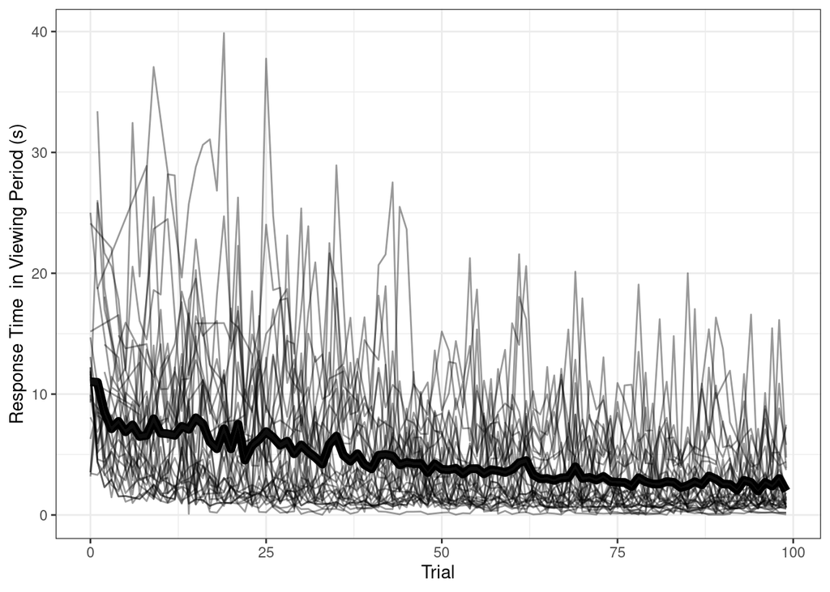

```r
d %>%
  filter(!(is.na(accuracy))) %>%
  group_by(trial_count) %>%
  summarize(rt_sec = mean(prompt_rt_sec), se = sd(prompt_rt_sec) / N) %>%
  ggplot(aes(x = trial_count, y = rt_sec)) +
  geom_line(data = s_data, aes(group = participant), alpha = .4) +
  geom_line(size = 2.5) +
  geom_ribbon(aes(ymin = rt_sec - se, ymax = rt_sec + se), alpha = .3) +
  labs(
    x = 'Trial',
    y = 'Response Time  in Viewing Period (s)'
  ) +
  theme_bw()
```

It does decrease over time, although maybe not as much as I expected, as people are still spending an average of about three secs looking in the viewing period even toward the end of the study, which is higher than I would’ve expected. We have some subjects who are spending 10-15 secs in that viewing period.

## Between-participant differences in view time and selection time

I’m going to think of this a bit like a clustering analysis. I’ll plot subjects as points in a 2D space between average view time and average selection time.

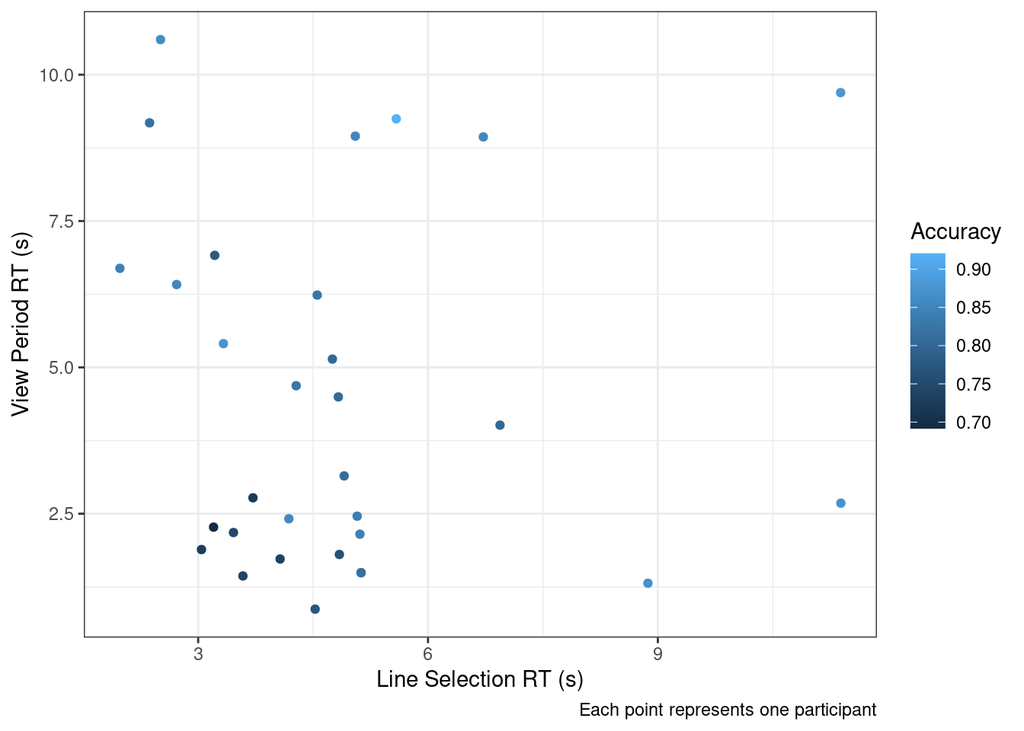

```r
## this computation includes in selection time the time it took them to press the submit button
## also im including line releases
d %>%
  group_by(participant) %>%
  summarize(prompt_rt_sec = mean(prompt_rt_sec), selection_rt_ms = mean(selection_rt_ms), accuracy = mean(accuracy, na.rm = TRUE)) %>%
  ggplot(aes(x = selection_rt_ms/1000, y = prompt_rt_sec)) +
  geom_point(aes(color = accuracy)) +
  labs(
    x = 'Line Selection RT (s)',
    y = 'View Period RT (s)',
    color = 'Accuracy',
    caption = 'Each point represents one participant'
  ) +
  theme_bw()
```

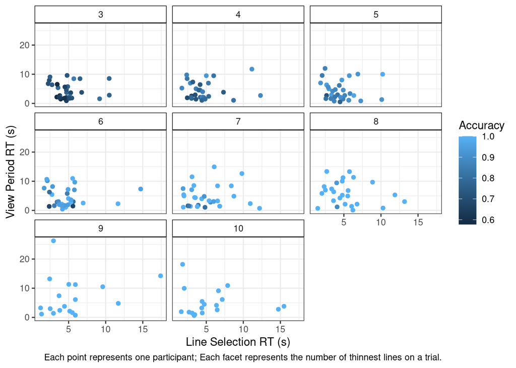

```r
d %>%
  filter(possible_thinnest_lines < 11) %>%
  group_by(participant, possible_thinnest_lines) %>%
  summarize(prompt_rt_sec = mean(prompt_rt_sec), selection_rt_ms = mean(selection_rt_ms), accuracy = mean(accuracy, na.rm = TRUE)) %>%
  ggplot(aes(x = selection_rt_ms/1000, y = prompt_rt_sec)) +
  geom_point(aes(color = accuracy)) +
  labs(
    x = 'Line Selection RT (s)',
    y = 'View Period RT (s)',
    color = 'Accuracy',
    caption = 'Each point represents one participant; Each facet represents the number of thinnest lines on a trial.'
  ) +
  facet_wrap(~possible_thinnest_lines) +
  theme_bw() +
  theme(strip.background = element_rect(color = 'black', fill = 'white'))
```

```r
ggsave('selection_times.png', height = 5.5, width = 7.5, units = 'in')
```

A work by [Dave Braun](https://davebraun.net)

*dab414@lehigh.edu*